# [Umer Saeed](https://www.linkedin.com/in/engumersaeed/)

Sr. RF Planning & Optimization Engineer  
BSc Telecommunications Engineering, [School of Engineering](https://sen.umt.edu.pk/)  
MS Data Science, School of Business and Economics  
**University of Management & Technology, Lahore, Pakistan**  
**Mobile:** +923018412180  
**Email:** umersaeed81@hotmail.com  
**Address:** Dream Gardens,Defence Road, Lahore

# **Chapter 1: Introduction to Python**

# Table of Contents

## **Chapter 1: Introduction to Python**

## 1.1 Programming basics

- **Code or Source Code**
  - The sequence of instructions in a program.
- **Syntax**
  - The set of legal structures and commands that can be used in a particular programming language.
- **Output**
  - The messages printed to the user by a program.
- **Console**
  - The text box onto which output is printed.
  - Some source code editors pop up the console as an external window, and others contain their own console window.

## 1.2 Reasons to become a Python Developer

- Python is one of the most trending and fast-growing programming languages.
- It is one of the easiest programming language and very ideal for beginners.
- It is an Open source programming language so it is free to use.
- With less code, we can create an effective program.
- It has an insane number of libraries, for each project you would have a library.
- It is a versatile programming language once you choose it, it opens a hell lot of door for you.
- Python developer paid well for their skill sets.
- Python is an object-oriented programming language.
- Python is a high level programming language
- To start Python from the command prompt, use the command 'python'
- Correct file extension for Python files is '.py'
- PyChecker and Pylint tools available to help find bugs, or perform static analysis

## 1.3 Open source Software Characteristics

- The freedom to run the program, for any purpose.
- The freedom to study how the program works, and adapt it to your needs. Access to the source code is a precondition for this.
- The freedom to redistribute copies so you can help your neighbor.
- The freedom to improve the program, and release your improvements to the public, so that the whole community benefits. Access to the source code is a precondition for this.

## 1.4 Python History

- [Reference Video](https://youtu.be/J0Aq44Pze-w)
- Python was developed in the late eighties i.e. late 1980's by [Guido van Rossum](https://en.wikipedia.org/wiki/Guido_van_Rossum) at the [National Research Institute for Mathematics and Computer Science in the Netherlands](https://www.cwi.nl/) as a successor of ABC language capable of exception handling and interfacing.
- Python is derived from programming languages such as [ABC](https://homepages.cwi.nl/~steven/abc/), [Modula 3](http://www.modula3.org/), [small talk](https://www.codeproject.com/Articles/1241904/Introduction-to-the-Smalltalk-Programming-Language), [Algol-68](http://www.math.bas.bg/bantchev/place/algol68.html).
- Python page is a file with a .py extension that contains could be the combination of [HTML Tags](https://html.com/tags/) and Python scripts.
- In December 1989 the creator developed the 1st python interpreter as a hobby and then on 16 October 2000, [Python 2.0](https://www.python.org/download/releases/2.0/) was released with many new features.
- On 3rd December 2008, [Python 3.0](https://www.python.org/download/releases/3.0/) was released with more testing and includes new features.
- Python is an [open source](https://opensource.com/resources/what-open-source) scripting language.
- Python is [free to download and use](https://repo.anaconda.com/archive/Anaconda3-2020.07-Windows-x86_64.exe).

### 1.4.1 Python Documentation by Version

- [Reference URL](https://www.python.org/doc/versions/)
- Python 3 is a newer version, but it is not backward compatible with Python 2. [Reference Video](https://www.youtube.com/watch?v=WT-gS-8p7KA)

## 1.5 Characteristics and Features of Python

- [Reference Video](https://youtu.be/1dfn8JpwBL8)
- **Interpreted Language**
  - Python is processed at runtime by Python Interpreter.
- **Object-Oriented Language**
  - It supports object-oriented features and techniques of programming.
- **high level programming language**
  - Python is a high level programming language
- **Interactive Programming Language**
  - Users can interact with the python interpreter directly for writing programs.
  - Easy to manage the objects and memory
- **Easy language**
  - Python is easy to learn, easy to read and easy to maintain language especially for beginners.
- **Straightforward Syntax**
  - Grammar of python is very simple when compare with C++
  - The formation of python syntax is simple and straightforward which also makes it popular.
  - Python syntax is case-sensitive.
- **Easy to read**
  - Python source-code is clearly defined and visible to the eyes.
- **Portable**
  - Python codes can be run on a wide variety of hardware platforms having the same interface.
- **Extendable**
  - Users can add low level-modules to Python interpreter.
- **Scalable**
  - Python provides an improved structure for supporting large programs then shell-scripts.
- **Advanced Features**
  - Advanced features (Function Programming, Iterator, Generator, Closure, Decorator and meta-class)
- **Dynamic data binding**
  - [Reference URL](https://www.geeksforgeeks.org/why-python-is-called-dynamically-typed/)
- **Automatic garbage collection**
  - Reference URL

### 1.5.1 Disadvantages

- [Reference URL](http://net-informations.com/python/iq/disadvantages.htm)
- **Speed**
  - Python is slower than [C or C++](https://www.cprogramming.com/). But of course, Python is a high-level language, unlike [C or C++](https://www.cprogramming.com/) it's not closer to hardware.
  - Yes, it possible to link a Python program to code written in C (C code can be in a form of a dynamically or a statically linked library)
- **Mobile Development**
  - Python is not a very good language for mobile development . It is seen as a weak language for mobile computing. This is the reason very few mobile applications are built in it like Carbonnelle.
- **Memory Consumption**
  - Python is not a good choice for memory intensive tasks. Due to the flexibility of the data-types, Python's memory consumption is also high.
- **Database Access**
  - Python has limitations with database access . As compared to the popular technologies like [JDBC](https://docs.oracle.com/javase/8/docs/technotes/guides/jdbc/) and [ODBC](https://www.simba.com/resources/odbc/), the Python's database access layer is found to be bit underdeveloped and primitive . However, it cannot be applied in the enterprises that need smooth interaction of complex legacy data.
- **Runtime Errors**
  - Python programmers cited several issues with the design of the language. Because the language is dynamically typed , it requires more testing and has errors that only show up at runtime

### 1.5.2 REPL

- A REPL (say it, “REP-UL”) is an interactive way to talk to your computer in Python. To make this work, the computer does four things:
  - 1- Read the user input (your Python commands).
  - 2- Evaluate your code (to work out what you mean).
  - 3- Print any results (so you can see the computer’s response).
  - 4- Loop back to step 1 (to continue the conversation).
- The term “REPL” is an acronym for Read, Evaluate, Print and Loop because that’s precisely what the computer does..!
- [Reference Video](https://www.youtube.com/watch?v=6xpPkRJzyIY)
- [Reference URL](https://codewith.mu/en/tutorials/1.0/repl)

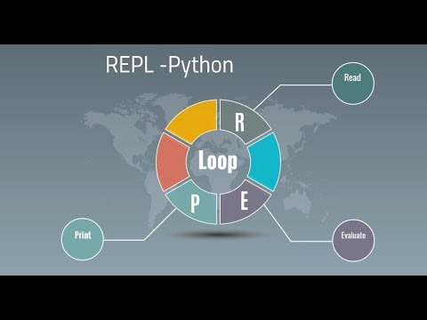

```python
from IPython.display import Image
Image(filename='REPL.jpg')
```

## 1.6 Python Overview

- [YouTubeVideo](https://youtu.be/Y8Tko2YC5hA)
- [Python](https://www.python.org/) is a general-purpose [object-oriented programming language](https://www.datacamp.com/community/tutorials/python-oop-tutorial) with [high-level programming](https://xccelerate.co/blog/why-python-a-high-level-programming-language) capabilities.
- **Great for backend**
  - Web Development
  - Data Analysis
  - Artificial Intelligence
  - Scientific Computing
  - System Software
  - Games
  - Image Processing
  - Distributed Software

[figure not shown]

```python
Image(filename='BP.jpeg')
```

- **Ptenty of Resources**
  - *Libararies*
    - [Pandas](https://pandas.pydata.org/)
    - [Numpy](https://numpy.org/)
    - [Matplotlib](https://matplotlib.org/)
    - [scikit-learn](https://scikit-learn.org/stable/)
    - etc
  - *Communities*
    - [GitHub](https://github.com/)
    - [Stackoverflow](https://stackoverflow.com/)
  - *Multi-platporms*
    - [Windows](https://www.microsoft.com/en-us/windows)
    - [MacOS](https://www.apple.com/macos/catalina/)
    - [Linux](https://www.linux.org/)
  - *Industry Interest:* Many large companies are using python to develop products.
    - [Google](https://www.google.com/)
    - [Microsoft](https://www.microsoft.com/en-pk)
    - **[Huawei](https://www.huawei.com/en/)**

## 1.7 What is Anaconda, Jupyter Notebook and Spyder in Python

- [Reference Video](https://youtu.be/Uyeu3m3BSXw?t=23)

## 1.7.1 Installing Anaconda on Windows

- [Reference Video](https://youtu.be/T8wK5loXkXg)
- Windows doesn’t come with Python installed.
- You can get a basic copy of Python from the [anaconda site](https://www.anaconda.com/products/individual).
- The following procedure should work fine on any Windows system, whether you use the 32-bit or the 64-bit version of Anaconda.

[figure not shown]

[figure not shown]

```python
Image(filename='Anaconda_installers.png')
```

**Locate the downloaded copy of Anaconda on your system:**

- The name of this file varies, but normally it appears as **Anaconda3-2020.07-Windows-x86_64.exe** for for 64-bit Windows systems.
- If you use some other version, you may experience problems with the source code and need to make adjustments when working with it.

**Double-click the installation file**

- You may see an Open File – Security Warning dialog box that asks whether you want to run this file. Click Run if you see this dialog box pop up;

[figure not shown]

```python
Image(filename='1.JPG')
```

- You see an **Anaconda3-2020.07(64-bit)** Setup dialog box similar to the one shown in Figure.
- The exact dialog box that you see depends on which version of the Anaconda installation program you download.
- If you have a 64-bit operating system, using the 64-bit version of Anaconda is always best so that you obtain the best possible performance.
- This first dialog box tells you when you have the 64-bit version of the product.

[figure not shown]

```python
Image(filename='2.JPG')
```

- Click on **“Next”**.
- The wizard displays a licensing agreement. Be sure to read through the licensing agreement so that you know the terms of usage!

[figure not shown]

```python
Image(filename='3.JPG')
```

- Click on **“I Agree”** if you agree to the licensing agreement
- You’re asked what sort of installation type to perform, as shown in Figure. In most cases, you want to install the product just for yourself. The exception is if you have multiple people using your system and they all need access to Anaconda!

[figure not shown]

```python
Image(filename='4.JPG')
```

- Choose one of the installation types and then **click Next**
- The wizard asks where to install Anaconda on disk, as shown in Figure. The presentation assumes that you use the default location.

[figure not shown]

```python
Image(filename='5.JPG')
```

[figure not shown]

```python
Image(filename='6.JPG')
```

- Change the advanced installation options (if necessary) and then **click Install**
- You see an Installing dialog box with a progress bar.
- The installation process can take a few minutes, so get yourself a cup of coffee and read the comics for a while.
- When the installation process is over, you see a **Next button enabled**

[figure not shown]

```python
Image(filename='7.JPG')
```

[figure not shown]

```python
Image(filename='8.JPG')
```

- Click on **“Next”**
- The wizard tells you that the installation is complete.
- You’re ready to begin using Anaconda

[figure not shown]

```python
Image(filename='9.JPG')
```

Click on “Finish”

## 1.8 Python IDE

- [YouTubeVideo](https://youtu.be/7bGOXbqhaow)
- There are various [GUI](https://techterms.com/definition/gui) based Python IDE that python programmers can use for better coding experience.
- General Editors and IDEs with Python Support
  - 1- [Eclipse + PyDev](https://www.pydev.org/)
  - 2- [Sublime Text](https://www.sublimetext.com/)
  - 3- [Atom](https://atom.io/)
  - 4- [GNU Emacs](https://www.gnu.org/software/emacs/)
  - 5- [Vi / Vim](https://www.vim.org/viusers.php)
  - 6- [Visual Studio](https://visualstudio.microsoft.com/)
  - 7- [Visual Studio Code](https://visualstudio.microsoft.com/)
- Python-Specific Editors and IDEs
  - 1- [PyCharm](https://www.jetbrains.com/pycharm/)
  - 2- [Spyder](https://www.spyder-ide.org/)
  - 3- [Thonny](https://thonny.org/)
- **Why Use IDE’s**
  - Save and reload code files
  - Run code from within the environment
  - Debugging support
  - Syntax highlighting: Being able to quickly spot keywords, variables, and symbols in your code makes reading and understanding code much easier
  - Automatic code formatting
  - **IntelliSense:** code editing features including: codecompletion, parameter info, quick info, and member lists.
- **Online Interpreters**
  - Python.org Online Console
  - Python Fiddle
  - Repl.it
  - Trinket
  - Python Anywhere

## 1.9 Jupyter Notebook

- [YouTubeVideo](https://youtu.be/EEEZX_0FMEc)
- Type [jupyter notebook](https://jupyter.org/) at the command line to open the dashboard
- Don't close the command line window while the Notebook is running
- **Keyboard shortcuts**
  - Create new cells above (a) or below (b) the current cell
  - Navigate using the up arrow and down arrow
  - Convert the cell type to Markdown (m) or code (y)
  - See keyboard shortcuts using h
  - Switch to Edit mode using Enter
  - Ctrl+Enter to run a cell
  - Switch to Command mode using Esc

### 1.9.1 How to use Jupter Notebook

[figure not shown]

```python
Image(filename='W.png')
```

- Jupter will open in browser.

[figure not shown]

```python
Image(filename='W1.jpg')
```

- Also the following Window will open, donot close the following Windows till your are working on Jupyter.

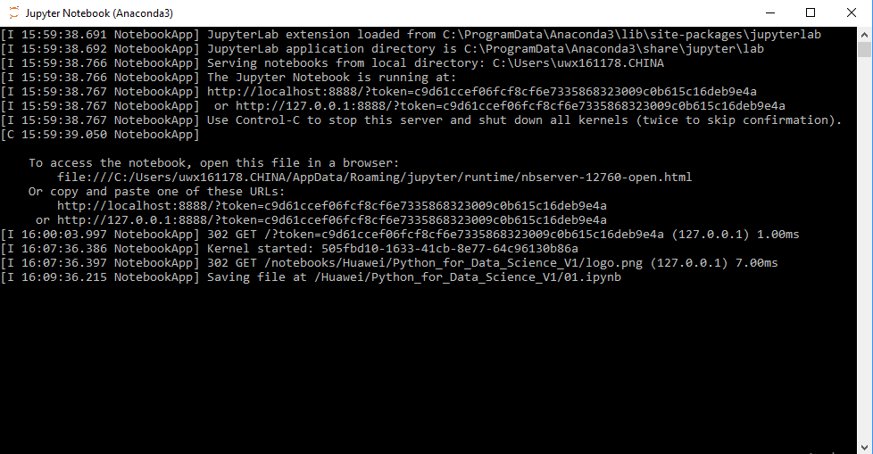

```python
Image(filename='W2.png')
```

### 1.9.2 How to Make a Folder in Jupyter

- **Step-1:** Click on 'New'
- **Step-2:** Clikc on 'Folder'

[figure not shown]

```python
Image(filename='W3.jpg')
```

[figure not shown]

```python
Image(filename='W4.jpg')
```

### 1.9.3 How to rename a Folder in Jupyter

- **Step-1:** To re-name the folder 1st we have to check the box.
- **Step-2:** Click on re-name
- **Step-3:** Rename directory

[figure not shown]

```python
Image(filename='W5.jpg')
```

### 1.9.4 How to Make a File in Jupyter

- **Step-1:** Click on 'New'
- **Step-2:** Clikc on 'Python 3'

[figure not shown]

```python
Image(filename='W6.jpg')
```

### 1.9.5 How to rename a File in Jupyter

- Click on 'Untitled'

[figure not shown]

```python
Image(filename='W7.jpg')
```

- Slect New File Name.
- Click on Rename.

[figure not shown]

```python
Image(filename='W8.jpg')
```

[figure not shown]

```python
Image(filename='W9.jpg')
```

## 1.10 How to check the installed version of Python

- [Reference Video](https://www.youtube.com/watch?v=CaFEo-pND94)

**Method-1**

```python
from platform import python_version
print(python_version())
```

```
3.8.5
```

**Method-2**

```python
import sys
print(sys.executable)
print(sys.version)
print(sys.version_info)
```

```
C:\Users\uwx161178.CHINA\Anaconda3\python.exe
3.8.5 (default, Sep  3 2020, 21:29:08) [MSC v.1916 64 bit (AMD64)]
sys.version_info(major=3, minor=8, micro=5, releaselevel='final', serial=0)
```

## 1.11 How to check the Libraries version use in the Current Jupter Notebook

### 1.11.1 Install watermark

```python
import sys
!{sys.executable} -m pip install watermark
```

### 1.11.2 Libraries version

```python
%load_ext watermark
%watermark --iversions
```

```
sys: 3.8.5 (default, Sep  3 2020, 21:29:08) [MSC v.1916 64 bit (AMD64)]
```

- [Go To Index](https://github.com/Umersaeed81/PythonForDataScienceV0/blob/main/README.md)
- [Go To Chapter2](https://htmlpreview.github.io/?https://github.com/Umersaeed81/PythonForDataScienceV0/blob/main/Chapter2.html)